# 5_grafos

## Network of partial friendship relations in Santa Barbara.

We will attempt to construct a graph-based network of friendship realities in a metropolitan area. We will choose the city with the fewest restaurants and limit the number of users studied to avoid problems with the memory needed for the calculations.

```python
import pandas as pd
import numpy as np
import json
import os
import re
import matplotlib.pyplot as plt
import seaborn as sns
import gc
import datetime
```

```python
from psutil import virtual_memory
print(f'Working with {round(virtual_memory().total / 1e9,2)} gigas of RAM.')
```

```
Working with 27.33 gigas of RAM.
```

```python
from google.colab import drive
drive.mount('/content/drive')
```

```python
os.chdir('/content/drive/MyDrive/yelp/notebooks')
```

```python
# read restaurant dataframe
data_bus = pd.read_parquet(r'../data/restaurants/restaurants_open_definitive.parquet')
```

```python
data_bus.metro_area.value_counts()
```

```
Philadelphia     11184
Tampa             5911
Saint Louis       3445
Nashville         3028
Indianapolis      2834
New Orleans       2339
Tucson            1799
Edmonton          1734
Reno              1072
Boise              938
Santa Barbara      666
Name: metro_area, dtype: int64
```

```python
data_bus.columns
```

```
Index(['business_id', 'name', 'address', 'city', 'state', 'postal_code',
       'latitude', 'longitude', 'stars', 'review_count', 'is_open',
       'metro_area', 'category_1', 'category_2', 'category_3', 'category_4',
       'category_5', 'category_6', 'category_7', 'category_8', 'category_9',
       'category_10', 'category_11', 'category_12', 'Alcohol', 'BikeParking',
       'BusinessAcceptsBitcoin', 'BusinessAcceptsCreditCards',
       'BusinessParking', 'ByAppointmentOnly', 'Caters', 'DogsAllowed',
       'DriveThru', 'GoodForKids', 'HappyHour', 'HasTV', 'Music', 'NoiseLevel',
       'OutdoorSeating', 'RestaurantsAttire', 'RestaurantsDelivery',
       'RestaurantsGoodForGroups', 'RestaurantsPriceRange2',
       'RestaurantsReservations', 'RestaurantsTableService',
       'RestaurantsTakeOut', 'WheelchairAccessible', 'WiFi', 'romantic',
       'intimate', 'touristy', 'hipster', 'divey', 'classy', 'trendy',
       'upscale', 'casual', 'dessert', 'latenight', 'lunch', 'dinner',
       'brunch', 'breakfast', 'Friday_work_hours', 'Monday_work_hours',
       'Saturday_work_hours', 'Sunday_work_hours', 'Thursday_work_hours',
       'Tuesday_work_hours', 'Wednesday_work_hours'],
      dtype='object')
```

```python
# select only restaurants in Santa Barbara
data_ss=data_bus[data_bus.metro_area=='Santa Barbara']['business_id'].to_frame()
```

```python
# read restaurant reviews
reviews=pd.read_parquet(r'../data/restaurants/restaurants_reviews.parquet')
```

```python
# merge to select Santa Barbara restaurant´s reviews
user_ss=  pd.merge(data_ss, reviews, on='business_id', how='inner')
```

```python
# Obtain users with Santa Barbara restaurant reviews.
user_ss = user_ss[['user_id']]
```

```python
# drop duplicates
user_ss = user_ss.drop_duplicates(keep = 'first')
```

```python
user_ss
```

|  | user_id |
| --- | --- |
| 0 | bFPdtzu11Oi0f92EAcjqmg |
| 1 | Ttb21DpWqphQMNSS5TXgMA |
| 2 | ha2Lv7WnxvdYnRsqwL1apQ |
| 3 | OVLf6NVTi7noMP1qCKr76w |
| 4 | 2ykh0_q0uMLFtypLDVSqlg |
| ... | ... |
| 167543 | z1SsbezNU_e-jSV__0KYLw |
| 167544 | oC_gXjHRkPBYDj0NI0CBow |
| 167545 | xNdacQLIGcyj6WLbdQ6Y-g |
| 167547 | _lM_tMmQgYdRdqXq8tghGA |
| 167549 | EQsdGSna-HHqzvSPTVx0Ew |

91243 rows × 1 columns

```python
# reading and select only Santa Barbara restaurant reviews.
users_json_path = r"../data/yelp_academic_dataset_user.json"
size = 100000
users = pd.read_json(users_json_path, lines=True,
chunksize = size)
```

```python
# Generate a list of chucks to be merged.
chunk_list = []
for chunk_review in users:

    # Inner merge with restaurant_id table to keep only restaurant reviews
    chunk_merged = pd.merge(user_ss, chunk_review, on='user_id', how='inner')
    # Show progress.
    print(f"{chunk_merged.shape[0]} out of {size:,} related reviews")
    chunk_list.append(chunk_merged)
# Concatenate all chunks in a dataframe.
df = pd.concat(chunk_list, ignore_index=True, join='outer', axis=0)
```

```
6720 out of 100,000 related reviews
4241 out of 100,000 related reviews
5715 out of 100,000 related reviews
3675 out of 100,000 related reviews
5873 out of 100,000 related reviews
3997 out of 100,000 related reviews
5739 out of 100,000 related reviews
3934 out of 100,000 related reviews
5437 out of 100,000 related reviews
3926 out of 100,000 related reviews
4283 out of 100,000 related reviews
3312 out of 100,000 related reviews
4976 out of 100,000 related reviews
4028 out of 100,000 related reviews
4579 out of 100,000 related reviews
3848 out of 100,000 related reviews
4754 out of 100,000 related reviews
3799 out of 100,000 related reviews
5133 out of 100,000 related reviews
3274 out of 100,000 related reviews
```

```python
# We erase memory frame and clean rubbish.
del [[data_bus,data_ss,reviews,user_ss,chunk_list]]
gc.collect()
```

```
0
```

```python
# Filteing users without freinds and less than 10 reviews.
df = df[df.friends != 'None']
df = df[df['review_count']>=10]
```

```python
df
```

[output not shown]

```python
# Select valid columns to graphs.
df = df[['user_id','friends' ]]
```

```python
# Transform frineds string to list.
df['list_friends']=df["friends"].apply(lambda x: str(x).split(','))
```

```python
# Valid columns.
df=df[['user_id','list_friends']]
```

```python
# Selecting 9000 first users to avoid memory ploblems
df=df.iloc[0:20000]
res = df.set_index(['user_id'])['list_friends'].apply(pd.Series).stack()
```

```python
network_data=res.reset_index()
#checks
network_data.tail()
```

|  | user_id | level_1 | 0 |
| --- | --- | --- | --- |
| 1951501 | BEV3L9KYnLr-xvwLOyqwlA | 8 | MsA07dbGYJc3EmR2a3TY5w |
| 1951502 | BEV3L9KYnLr-xvwLOyqwlA | 9 | 17sw8Ro4SxjGe6_5CNZyQQ |
| 1951503 | BEV3L9KYnLr-xvwLOyqwlA | 10 | Eop9kOuCD7oXKmhYR3bhiA |
| 1951504 | BEV3L9KYnLr-xvwLOyqwlA | 11 | QRccXTcsEIeIUhi-rwLQHQ |
| 1951505 | BEV3L9KYnLr-xvwLOyqwlA | 12 | CH1eqMBZwHrcS0xV8EYuQA |

```python
#Install valid version of networkx to aviod compatiby errors with scipy.
!pip uninstall networkx -y
! pip install 'networkx<2.7'
```

```
Found existing installation: networkx 2.8.8
Uninstalling networkx-2.8.8:
  Successfully uninstalled networkx-2.8.8
     ━━━━━━━━━━━━━━━━━━━━━━━━━━━━━━━━━━━━━━━━ 1.9/1.9 MB 24.7 MB/s eta 0:00:00
```

```python
#graph section
import networkx as nx
import heapq  # for getting top n number of things from list,dict

#changing the column name to suit nx import
network_data.columns=['source','level_1','target']

# Considering each (user_id,friend) pair as an edge of a graph, constructing the graph
graph=nx.from_pandas_edgelist(network_data)
```

```python
#basic info
print(nx.info(graph))
#check density
print("The density of the graph is ",nx.density(graph))
```

```
Graph with 985763 nodes and 1951498 edges
The density of the graph is  4.016553170471481e-06
```

The degree centrality of a node is a measure of the node's importance or influence in the graph. It is calculated as the number of edges that are incident to the node. In a social network, a person with a high degree centrality may be considered influential because they have many connections to other people.

We select the 4000 most connected nodes as influencers in our network. Afther that, we filter the subgraph only with this nodes.

Then, we make visualitations and community detection by Louvain algorithm.

```python
#use degree-centrality to find out influencers in the selected region
x=nx.degree_centrality(graph)
#Creating a subset again as we cant handle 70k nodes, unfortunately.

#Using heapq to find the 4000 most connected nodes (ie) people with the most connections
influencers=heapq.nlargest(4000, x, key=x.get)
```

```python
#creating a sub-graph as I'm not able to create the layout positions without killing the kernal
influencers_sub_graph=graph.subgraph(influencers)

# Check for isolates ( nodes with no edges (ie) users without friends in the sub-graph)
# graph=graph.remove_nodes_from(nx.isolates(graph))
list_of_nodes_to_be_removed=[x for x in nx.isolates(influencers_sub_graph)]

# remove the selected isolates from the main graph
graph.remove_nodes_from(list_of_nodes_to_be_removed)
```

```python
#recreate the subgraph from the updated graph
influencers_sub_graph=graph.subgraph(influencers)
```

```python
#basic info
print(nx.info(influencers_sub_graph))
#check density
print("The density of the graph is ",nx.density(influencers_sub_graph))
```

```
Graph with 3237 nodes and 110274 edges
The density of the graph is  0.021054838351217936
```

```python
# create the layout
pos = nx.spring_layout(influencers_sub_graph,scale=4)
```

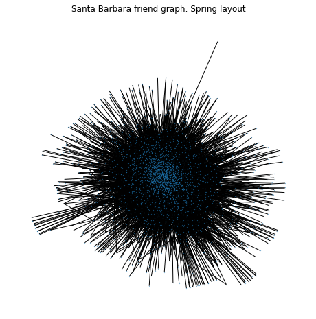

```python
plt.figure(figsize=(8,8))
plt.title("Santa Barbara friend graph: Spring layout")
nx.draw(influencers_sub_graph, pos=pos, node_size=0.05, width=1)
```

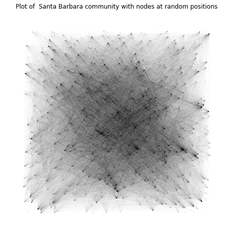

```python
plt.figure(figsize=(8,8))
plt.title("Plot of  Santa Barbara community with nodes at random positions")

nx.draw_random(influencers_sub_graph,node_size=0.001, width=0.001)
```

## Louvain algorithm.

The Louvain algorithm is a greedy optimization algorithm that is used to identify communities in a graph. It works by iteratively optimizing a metric called modularity, which measures the density of connections within communities compared to connections between communities.

The algorithm starts by assigning each node in the graph to its own community, and then it iteratively merges pairs of communities if doing so increases the modularity of the graph. It stops when it is no longer possible to increase the modularity by merging communities.

```python
#community detection
from community import community_louvain
parts = community_louvain.best_partition(influencers_sub_graph)
values = [parts.get(node) for node in influencers_sub_graph.nodes()]

print(len(set(values))," Communities have been identified")
```

```
5  Communities have been identified
```

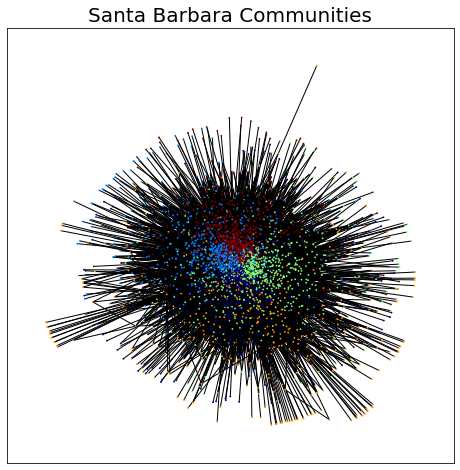

```python
plt.figure(figsize=(8,8))
plt.axes=False
plt.title("Santa Barbara Communities",fontsize=20)
nx.draw_networkx(influencers_sub_graph, pos = pos,cmap = plt.get_cmap("jet"), node_color = values, node_size = 0.6, with_labels = False)
```

```python
comunidades = pd.DataFrame.from_dict(parts, orient='index',columns=['comunidad'])
```

```python
comunidades.comunidad.value_counts()
```

```
4    758
2    722
1    662
0    653
3    442
Name: comunidad, dtype: int64
```

#### We can use this data in the future to:

Social network analysis: Communities in social networks often correspond to groups of people with similar interests or relationships. Community detection can be used to identify these groups and understand how they are connected.

Recommendation systems: In networks of users and products, communities can correspond to groups of users with similar interests or groups of products that are frequently purchased together. Community detection can be used to identify these groups and make recommendations to users based on their community membership.